# Download and Begin Processing Data

Ilyes Baali

2/22/2021

## Data Details

#### where did you get it from?

The data was downloaded from Gene Expression Omnibus (GEO) repository using the `GEO accession number:` [`GSE110417`](https://www.ncbi.nlm.nih.gov/geo/query/acc.cgi?acc=GSE110417)`

#### what publication is it linked to?

The data ws used in *Exploring the effect of library preparation on RNA sequencing experiments* [paper](https://www.sciencedirect.com/science/article/pii/S0888754318303677#s0010)

#### who generated the data?

**Pease, LR** and **Zhang, Y** were the contributors who generated the data.

#### how was the RNA extracted?

quoting from the data processing section of the sample `Isolated cells were resuspended at 1 million/ml in RPMI containing 10 % FBS and either immediately lysed in 0.7 ml QIAzol lysis reagent (Qiagen) or incubated for 4 h at 37 °C with 25 μl/ml anti-CD3/antiCD28 Human T-Activator Dynabeads (Invitrogen) prior to lysis. Lysates were stored at −80 °C until processing for RNAseq`

#### what library prep was used?

TruSeq RNA Library Prep Kit v2 was used for library preparation

#### what cell type was used?

B and CD4+ cells were used to prepare different samples.

#### what was the treatment/experimental condition?

The samples are divided into three experimental conditions, where for each condition some samples were prepared to examine the possible preparation factors that may impact the samples sequencing and the end results. The three factors are: 1- cDNA library storage time 2- RNA input concentration 3- Cryopreservation of cell samples

#### what sequencing platform was used?

Illumina HiSeq 2000 sequencing platform was used.

## Download FASTQ files

For my project the data I intend to use is stored in SRA repository. To download the data from SRA, I used `sra-toolkit` to fetch and extract the fastq files. First I obtained the SRR accession list for all the fastq files for the project. I obtained the list from `SRA Run Selector` using the `GEO accession number: GSE110417` [here](https://www.ncbi.nlm.nih.gov/Traces/study/?acc=PRJNA433678&o=acc_s%3Aa).

The following command is used to download all the files:

```bash
prefetch --option-file SRR_Acc_List.txt
```

The downloaded files are not a proper `.fastq` files that can be processed, instead `SRA-toolkit` downloads `.sra (Sequence Read Archive)` files. The next step `fastq-dump` tool (there is a faster tool named `fasterq-dump` that was not found on the cluster) is use to extract the `fastq` files from these archive files. The following script is used to extract all the files:

```bash
#! /bin/bash -l
#SBATCH --partition=angsd_class #SBATCH --nodes=1
#SBATCH --ntasks=1
#SBATCH --job-name=SRATofastq
#SBATCH --time=24:00:00 # HH/MM/SS
#SBATCH --mem=8G # memory requested, units available: K,M,G,T
outFile=${DownloadSRA}_${SLURM_JOB_ID}.txt
echo "Starting at:" `date` >> ${outFile}
echo "This is job #:" $SLURM_JOB_ID >> ${outFile}
echo "Running on node:" `hostname` >> ${outFile}
echo "Running on cluster:" $SLURM_CLUSTER_NAME >> ${outFile}
echo "This job was assigned the temporary (local) directory:" $TMPDIR >> ${outFile}

spack load -r sra-toolkit
for file in *.sra; do
   echo "File Name: " $file >> ${outFile}
   fastq-dump --split-files --gzip $file
done
exit
```

The parameters that are used in the previous step are `--split-files` and `--gzip`. The first one is used to save the pair-end reads to two separate files, and the second is used to save the extracted `fastq` file to `gzip` compressed file. The documentation from the tool are displayed bellow:

```bash
--split-files    Dump each read into separate file.Files
                 will receive suffix corresponding to read
                 number
--gzip           Compress output using gzip
```

For the purpose of this assignment I will use `SRR6703962` sample.

## `FastQC` Analysis

First the fastqc report for pair-end fastq files was obtained using the following command:

```bash
#! /bin/bash -l

#SBATCH --partition=angsd_class
#SBATCH --nodes=1
#SBATCH --ntasks=4
#SBATCH --job-name=hi_slurm
#SBATCH --time=05:00:00 # HH/MM/SS
#SBATCH --mem=8G # memory requested, units available: K,M,G,T
outFile=${Fastqc}_${SLURM_JOB_ID}.txt
echo "Starting at:" `date` >> ${outFile}
echo "This is job #:" $SLURM_JOB_ID >> ${outFile}
echo "Running on node:" `hostname` >> ${outFile}
echo "Running on cluster:" $SLURM_CLUSTER_NAME >> ${outFile}
echo "This job was assigned the temporary (local) directory:" $TMPDIR >> ${outFile}

spack load -r fastqc

mkdir ${TMPDIR}/ilb4001
tmp=${TMPDIR}/ilb4001

echo "Copying fastq files to" ${tmp} >> ${outFile}
cp $SLURM_SUBMIT_DIR/raw_data/SRR6703962_*.fastq ${tmp}

mkdir ${tmp}/fastqc
resultFolder=${tmp}/fastqc/

echo "Start fastqc...." >> ${outFile}
fastqc ${tmp}/SRR6703962_*.fastq --extract -o ${resultFolder} |$ tee ${outFile}

echo "copying the results back...." >> ${outFile}
mkdir ${SLURM_SUBMIT_DIR}/SRR6703962

cp -r ${resultFolder}/* ${SLURM_SUBMIT_DIR}/SRR6703962/

echo "remove tmp directory" >> ${outFile}
rm -r ${tmp}
echo "Done!" >> ${outFile}

exit
```

The results from the analysis was all good, except for the first reads file, where two sequences were over-represented as shown in Figure 1. For that, the next step was to run `Trimglore` to trim the over-represented sequences.

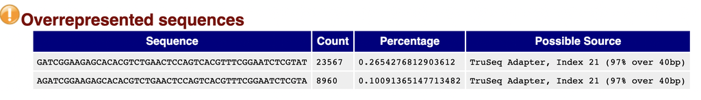

Figure 1: Two sequences over represented in the first pair of reads

### `TrimGalore` Tool

```bash
srun -n1 --pty --partition=angsd_class --mem=8G bash -i
spack load -r trimgalore
trim_galore --illumina raw_data/SRR6703962_*.fastq.gz --stringency 5 -o fastq_trimmed/
```

## Reads Alignment

### Downlaod the required files

To align the reads a number two main files are required: 1- Genome file and 2- Annotation file Since the samples for the project are human, the human genome fa file is downloaded. For the annotation file we have different choices that we can use depending on the use case. Since we are not dealing with special annotation Ensemble gene annotation file `hg38.ensGene.gtf.gz` is used.

The following script is used to download the files from [UCSC Browser](https://hgdownload.soe.ucsc.edu/goldenPath/hg38/bigZips/):

```bash
# Create a folder to save the files
mkdir genome
cd genome

# Download Human genome hg38 fa file.
wget --timestamping  'ftp://hgdownload.cse.ucsc.edu/goldenPath/hg38/bigZips/hg38.fa.gz' -O hg38.fa.gz

gunzip hg38.fa.gz

# Download Human genome annotation files. I downloaded everything at first,
# and later I decided what annotation file to use
# The annotation files are:
# 1- hg38.ensGene.gtf.gz
# 2- hg38.knownGene.gtf.gz
# 3- hg38.ncbiRefSeq.gtf.gz
# 4- hg38.refGene.gtf.gz
wget --timestamping 'ftp://hgdownload.cse.ucsc.edu/goldenPath/hg38/bigZips/genes/*'

gunzip hg38.ensGene.gtf.gz
```

### Generate Index and Align Reads

```bash
#! /bin/bash -l

#SBATCH --partition=angsd_class
#SBATCH --nodes=1
#SBATCH --ntasks=16
#SBATCH --job-name=IndexGenerator
#SBATCH --time=12:00:00 # HH/MM/SS
#SBATCH --mem=36G # memory requested, units available: K,M,G,T
outFile=IndexAlign_${SLURM_JOB_ID}.txt
echo "Starting at:" `date` >> ${outFile}
echo "This is job #:" $SLURM_JOB_ID >> ${outFile}
echo "Running on cluster:" $SLURM_CLUSTER_NAME >> ${outFile}
echo "This job was assigned the temporary (local) directory:" $TMPDIR >> ${outFile}

spack load star@2.7.0e


mkdir ${TMPDIR}/ilb4001
tmp=/scratchLocal/ilb4001

echo "Copying files to" ${tmp} >> ${outFile}

# Copy genome and annotation file
cp $SLURM_SUBMIT_DIR/hg38.fa ${SLURM_SUBMIT_DIR}/hg38.ensGene.gtf ${tmp}

# Copy sample read fastq files
cp $SLURM_SUBMIT_DIR/fastq_trimmed/SRR6703962_1_val_1.fq ${SLURM_SUBMIT_DIR}/fastq_trimmed/SRR6703962_2_val_2.fq ${tmp}

# Check that all the files were copied without an error
echo "tmp content..."
ls ${tmp} | cat >> ${outFile}

############################Indexing######################################
resultFolder=${tmp}/hg38_STARindex
mkdir ${resultFolder}

echo "STAR genomeGenerate...." >> ${outFile}

STAR --runMode genomeGenerate \
--runThreadN 16 \
--genomeDir ${resultFolder} \
--genomeFastaFiles hg38.fa \
--sjdbGTFfile hg38.ensGene.gtf \
--sjdbOverhang 49 \
|& tee ${outFile}


echo "copying the generated index...." >> ${outFile}
cp -r ${resultFolder}/* ${SLURM_SUBMIT_DIR}/genome/hg38_STARindex/

############################Alignment######################################
echo "STAR Alignment...." >> ${outFile}

resultFolder=${tmp}/alignments
mkdir ${resultFolder}


STAR --runMode alignReads \
--runThreadN 16 \
--readFilesIn ${tmp}/SRR6703962_1_val_1.fq  ${tmp}/SRR6703962_2_val_2.fq \
--genomeDir ${tmp}/hg38_STARindex \
--outSAMtype BAM SortedByCoordinate \
--outFileNamePrefix ${resultFolder}/SRR6703962.

echo "coying the results back...." >> ${outFile}
cp -r ${resultFolder}/alignments/* ${SLURM_SUBMIT_DIR}/alignments

echo "remove tmp directory" >> ${outFile}
rm -r ${tmp}

echo "Check files removed from tmp folder" >> ${outFile}
ls ${tmp} | cat >> ${outFile}

echo "Done!" >> ${outFile}

exit
```

### Bamqc Analysis

Once the reads were aligned, we run another quality control check to make sure everything is done well and there are no concerns about the quality of reads or mapping. At this point we run `BamQC` using the following commands:

```bash
srun -n1 --pty --partition=angsd_class --mem=8G bash -i
spack load samtools@1.9% gcc@6.3.0

# Index bam file
samtools index alignments/SRR6703962.Aligned.sortedByCoord.out.bam

# Run BamQC
/softlib/apps/EL7/BamQC/bin/bamqc alignments/SRR6703962.Aligned.sortedByCoord.out.bam -o alignments/bamqc/
```

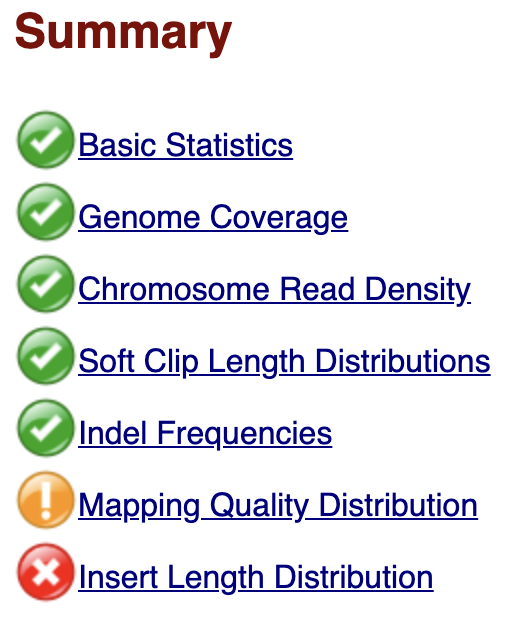

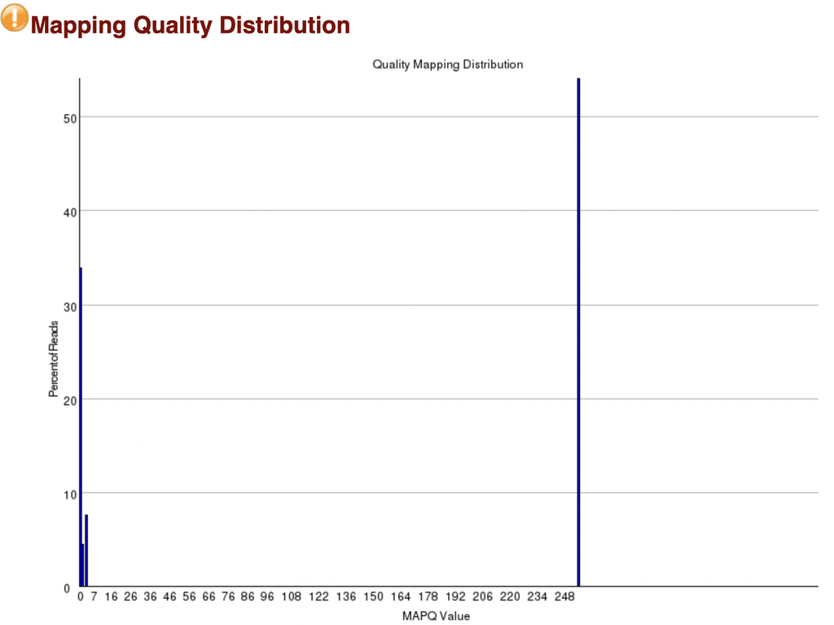

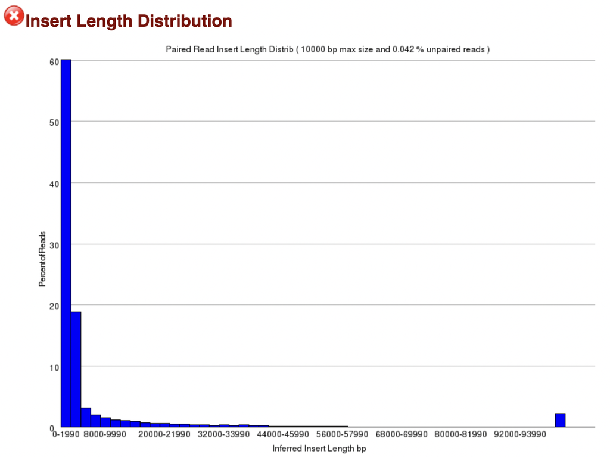

Here is the structure of the project’s folder:

```bash
├── genome
│   ├── hg38.ensGene.gtf
│   ├── hg38.fa
│   ├── hg38_STARindex\
├── raw_data
│   ├── SRR6703962_1.fastq.gz
│   ├── SRR6703962_2.fastq.gz
│   └── SRR_Acc_List.txt
├── fastqc
│   ├── SRR6703962_1_fastqc
│   ├── SRR6703962_2_fastqc.html
│   └── SRR6703962_2_fastqc.zip
├── fastq_trimmed
│   ├── SRR6703962_1.fastq_trimming_report.txt
│   ├── SRR6703962_1_val_1.fq
│   ├── SRR6703962_2.fastq_trimming_report.txt
│   └── SRR6703962_2_val_2.fq
├── alignments
│   ├── SRR6703962.Aligned.sortedByCoord.out.bam
│   ├── SRR6703962.Aligned.sortedByCoord.out.bam.bai
│   ├── SRR6703962.Log.final.out
│   ├── SRR6703962.Log.out
│   ├── SRR6703962.Log.progress.out
│   ├── SRR6703962.SJ.out.tab
│   ├── bamqc
│   │   ├── SRR6703962.Aligned.sortedByCoord.out_bamqc.html
│   │   └── SRR6703962.Aligned.sortedByCoord.out_bamqc.zip
```